# RNAseq analysis methods

1. Open R (I use R studio, you can also use the command line)
2. Install edgeR.

```r
source("http://bioconductor.org/biocLite.R")
biocLite("edgeR")
```

3. Load the edgeR package. We will use edgeR to identify significantly differentially expressed genes between our two groups based on counts of gene expression for each gene.

```r
library(edgeR)
```

```r
library(tidyverse)
```

Set working directory

```r
setwd("/Users/jlkelley/Dropbox/ConGen2018")
```

```
The working directory was changed to /Users/jlkelley/Dropbox/ConGen2018 inside a notebook chunk. The working directory will be reset when the chunk is finished running. Use the knitr root.dir option in the setup chunk to change the working directory for notebook chunks.
```

Read in gene count matrix

```r
counts = read.csv("gene_count_matrix.csv", header = T, row = 1)
```

Look at the beginning of the file (note, there are lots of zeros)

```r
head(counts)
```

|  | X01 | X02 | X03 | X04 | X05 | X06 | X07 | X08 | X09 | X10 | X11 | X12 | X13 | X14 | X15 | X16 | X17 | X18 | X19 | X20 |
| --- | --- | --- | --- | --- | --- | --- | --- | --- | --- | --- | --- | --- | --- | --- | --- | --- | --- | --- | --- | --- |
| IFT27 | 0 | 0 | 0 | 0 | 0 | 0 | 0 | 0 | 0 | 0 | 0 | 0 | 0 | 0 | 0 | 0 | 0 | 0 | 0 | 0 |
| DRICH1 | 0 | 0 | 0 | 0 | 0 | 0 | 0 | 0 | 0 | 0 | 0 | 0 | 0 | 0 | 0 | 0 | 0 | 0 | 0 | 0 |
| CRKL | 0 | 0 | 0 | 0 | 0 | 0 | 0 | 0 | 0 | 0 | 0 | 0 | 0 | 0 | 0 | 0 | 0 | 0 | 0 | 0 |
| LOC100996342 | 0 | 0 | 0 | 0 | 0 | 0 | 0 | 0 | 0 | 0 | 0 | 0 | 0 | 0 | 0 | 0 | 0 | 0 | 0 | 0 |
| MIR130B | 0 | 0 | 0 | 0 | 0 | 0 | 0 | 0 | 0 | 0 | 0 | 0 | 0 | 0 | 0 | 0 | 0 | 0 | 0 | 0 |
| SBF1 | 0 | 0 | 0 | 0 | 0 | 0 | 0 | 0 | 0 | 0 | 0 | 0 | 0 | 0 | 0 | 0 | 0 | 0 | 0 | 0 |

Make sure the number of genes and samples is expected

```r
dim(counts)
```

```
[1] 579  20
```

Create map of samples to treatments

```r
samples = colnames(counts)
group = c(rep("A", 10),rep("B",10))
sample.info = data.frame(cbind(samples,group))
head(sample.info)
```

|  | samples | group |
| --- | --- | --- |
| 1 | X01 | A |
| 2 | X02 | A |
| 3 | X03 | A |
| 4 | X04 | A |
| 5 | X05 | A |
| 6 | X06 | A |

Remove genes with zero counts

```r
length(which(rowSums(counts) == 0))
```

```
[1] 525
```

```r
gene.counts = counts[rowSums(counts) != 0,]
```

## Determine the number of genes left after removing zeros

```r
dim(gene.counts)
```

```
[1] 54 20
```

### Create a DGEList of the data

```r
y <- DGEList(counts=gene.counts,group=sample.info$group)
```

```r
y <- calcNormFactors(y)
```

Look at y

```r
y
```

```
An object of class "DGEList"
$counts
          X01  X02  X03  X04  X05  X06  X07  X08  X09  X10  X11  X12  X13
GSC2      307  366  448  360  522  371  388  391  392  462  392  375  392
ATP6V1E1 1725 1516 1788 1771 1758 1698 2016 1997 1799 1653 1926 1420 1869
CCT8L2    240  294  331  299  244  310  244  190  258  227  251  307  291
CDC45    2043 2216 1933 2491 2097 1986 2307 2162 2336 1962 2354 2273 2332
POTEH     612  544  845  608  499  769  537  849  573  682  163  155  107
          X14  X15  X16  X17  X18  X19  X20
GSC2      380  320  320  424  508  367  283
ATP6V1E1 1791 1864 2067 1764 1888 1898 1765
CCT8L2    275  286  176  190  354  343  251
CDC45    1954 2318 2263 2410 2208 2307 2213
POTEH     191  166  158  142  166  120  208
49 more rows ...

$samples
```

|  | group | lib.size | norm.factors |
| --- | --- | --- | --- |
| X01 | A | 102518 | 0.9934383 |
| X02 | A | 102408 | 1.0031192 |
| X03 | A | 102145 | 1.0166174 |
| X04 | A | 103087 | 1.0096601 |
| X05 | A | 102478 | 1.0193154 |

```
15 more rows ...
```

## Visualize the data in y, for example using an MDS plot

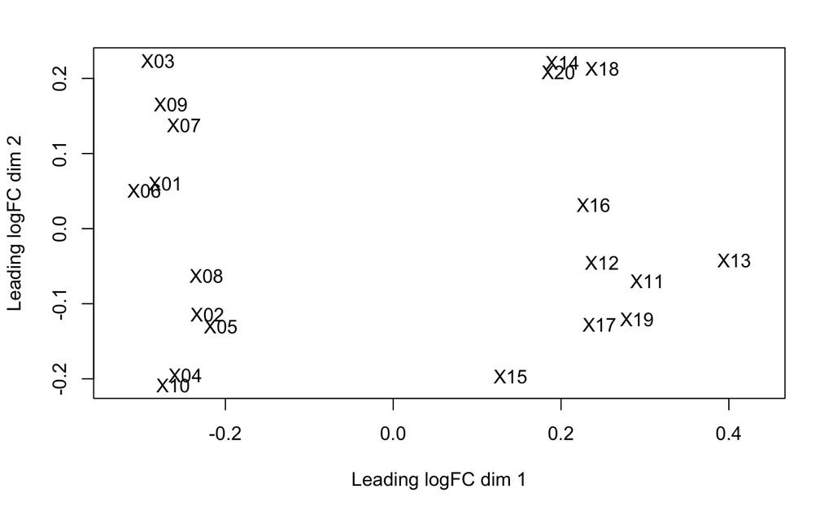

```r
plotMDS(y)
```

Design matrix

```r
design <- model.matrix(~group)
design
```

```
   (Intercept) groupB
1            1      0
2            1      0
3            1      0
4            1      0
5            1      0
6            1      0
7            1      0
8            1      0
9            1      0
10           1      0
11           1      1
12           1      1
13           1      1
14           1      1
15           1      1
16           1      1
17           1      1
18           1      1
19           1      1
20           1      1
attr(,"assign")
[1] 0 1
attr(,"contrasts")
attr(,"contrasts")$group
[1] "contr.treatment"
```

Estimate dispersion

```r
y <- estimateDisp(y,design)
```

perform quasi-likelihood F-tests:

```r
fit <- glmQLFit(y,design)
qlf <- glmQLFTest(fit,coef=2)
topTags(qlf)
```

```
Coefficient:  groupB
```

|  | logFC | logCPM | F | PValue | FDR |
| --- | --- | --- | --- | --- | --- |
| CLTCL1 | -0.90051922 | 14.41095 | 499.220714 | 2.467773e-18 | 1.332597e-16 |
| GGT3P | 1.28828275 | 12.55877 | 277.631550 | 2.847335e-15 | 5.950294e-14 |
| POTEH | -2.05640385 | 11.93874 | 274.133140 | 3.305719e-15 | 5.950294e-14 |
| PRODH | -0.75915668 | 14.00270 | 220.610558 | 4.155316e-14 | 5.609677e-13 |
| CECR1 | 0.56898420 | 15.41422 | 206.557138 | 8.856165e-14 | 9.564659e-13 |
| DGCR6 | 1.17567719 | 12.37898 | 175.702302 | 5.559834e-13 | 5.003850e-12 |
| OR11H1 | -1.90299912 | 11.24893 | 95.221352 | 4.049414e-10 | 3.123834e-09 |
| BCL2L13 | 0.18969445 | 17.03233 | 76.559552 | 3.558722e-09 | 2.402138e-08 |
| FLJ41941 | 0.48355971 | 10.10783 | 9.681299 | 4.527109e-03 | 2.716265e-02 |
| CECR2 | -0.08693882 | 14.94253 | 7.664298 | 1.031735e-02 | 5.571369e-02 |

summarize the results

```r
summary(de <- decideTestsDGE(qlf, p.value = 0.05))
```

```
       groupB
Down        4
NotSig     45
Up          5
```

plot the results

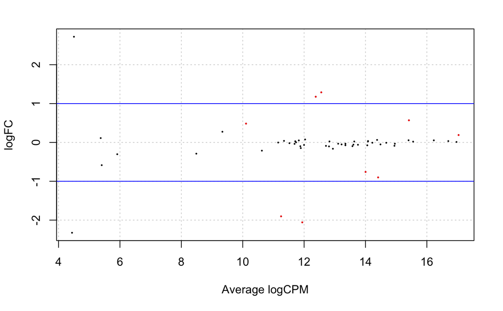

```r
detags <- rownames(y)[as.logical(de)]
plotSmear(qlf, de.tags=detags)
abline(h = c(-1, 1), col = "blue")
```

```r
as_tibble(mtcars)
```

|  | mpg | cyl | disp | hp | drat | wt | qsec | vs | am | gear | carb |
| --- | --- | --- | --- | --- | --- | --- | --- | --- | --- | --- | --- |
| 1 | 21.0 | 6 | 160.0 | 110 | 3.90 | 2.620 | 16.46 | 0 | 1 | 4 | 4 |
| 2 | 21.0 | 6 | 160.0 | 110 | 3.90 | 2.875 | 17.02 | 0 | 1 | 4 | 4 |
| 3 | 22.8 | 4 | 108.0 | 93 | 3.85 | 2.320 | 18.61 | 1 | 1 | 4 | 1 |
| 4 | 21.4 | 6 | 258.0 | 110 | 3.08 | 3.215 | 19.44 | 1 | 0 | 3 | 1 |
| 5 | 18.7 | 8 | 360.0 | 175 | 3.15 | 3.440 | 17.02 | 0 | 0 | 3 | 2 |
| 6 | 18.1 | 6 | 225.0 | 105 | 2.76 | 3.460 | 20.22 | 1 | 0 | 3 | 1 |
| 7 | 14.3 | 8 | 360.0 | 245 | 3.21 | 3.570 | 15.84 | 0 | 0 | 3 | 4 |
| 8 | 24.4 | 4 | 146.7 | 62 | 3.69 | 3.190 | 20.00 | 1 | 0 | 4 | 2 |
| 9 | 22.8 | 4 | 140.8 | 95 | 3.92 | 3.150 | 22.90 | 1 | 0 | 4 | 2 |
| 10 | 19.2 | 6 | 167.6 | 123 | 3.92 | 3.440 | 18.30 | 1 | 0 | 4 | 4 |

[output cut: 22 more lines]